# A Weather Report

Carl Howe, RStudio

8/21/2019

## Building A Report From The R Markdown Template

This document is created directly from the original RStudio R Markdown template. I simply typed in all the text you see below to replace the summary of *cars* and the graph of *pressure*.

```r
options(geonamesUsername="rstudio_dashboard")    #  Login name for geonames
LCY_observation    <- GNweatherIcao("EGLC")      # EGLC is London City
london_weather <- LCY_observation %>%            # Extract 5 columns
    select(stationName, datetime, temperature, humidity)
print(london_weather)
```

```
##           stationName            datetime temperature humidity
## 1 London City Airport 2019-09-04 12:20:00          20       42
```

## Inserting Links to Other Sites

It’s easy to include links to other sites. Simply put the text you want displayed in square brackets, followed by the target URL of the site in normal parentheses. Your link codeshould look like this:

```
[Text you want displayed for the link](https://link-target)
```

So to link to the BBC London Weather, you’d use this code:

```
[BBC London Weather](https://www.bbc.com/weather/2643743)
```

When it’s knit, this is what your link will look like.

[BBC London Weather](https://www.bbc.com/weather/2643743)

## Inserting Local Images

Local images are easy to include in R Markdown. The general form is as follows:

```
![Alternate text for image](path/to/image.png)
```

So to include an image of the London skyline that I’ve conveniently stored in the images directory for this R project, I’d write

```
![*London Skyline*](images/london_skyline.png)
```

Here’s what that photo looks like:

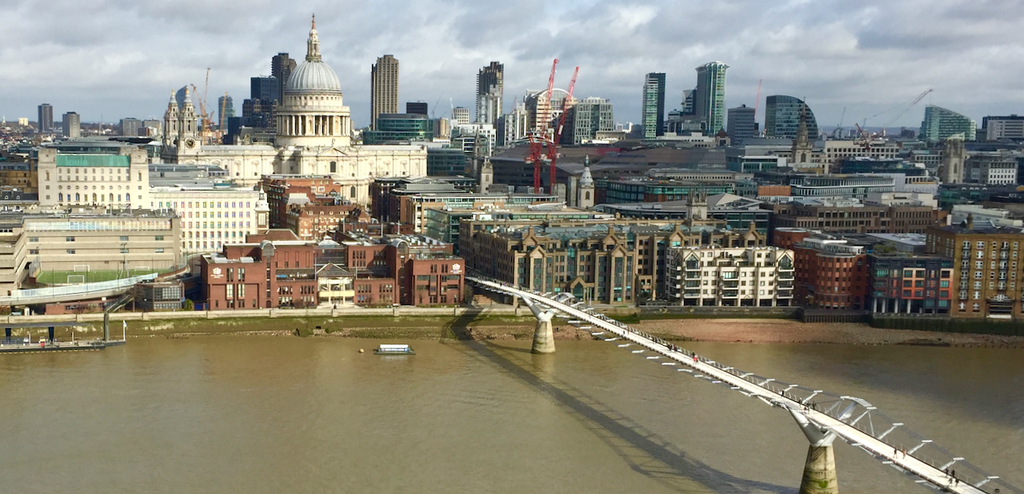

*London Skyline*

## Getting Images From Other Sites

But what if you don’t a copy of the image you want to include, but you know it’s available on the internet? In that case, you can use either the same insert the R function *include_graphics* from the *knitr* package.

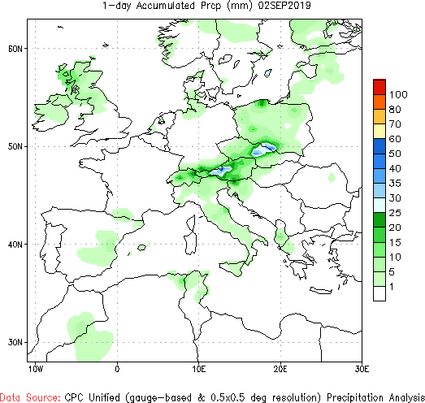

```r
knitr::include_graphics("https://www.cpc.ncep.noaa.gov/products/JAWF_Monitoring/Europe/daily/p.1day.figa.gif")
```

You can also embed dynamic images, provided that the web site returns the image a .png, a .jpg, or a .gif object. Here’s a real-time satellite image.

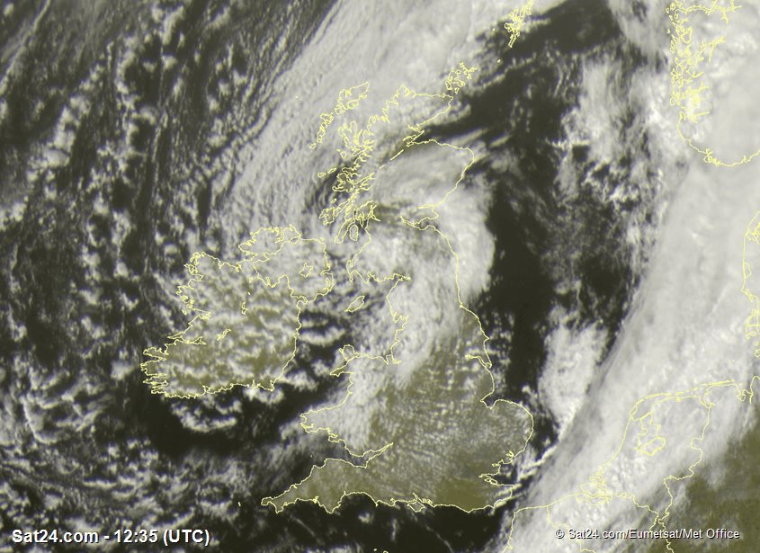

```r
knitr::include_graphics("https://en.sat24.com/image?type=visual&region=gb")
```